# 3_PHD_ML_Hackathon

1. Analysis of Customer Loan re-payment History and
2. Predicting credit risk score &
3. Customer Segmentation

Problem Description

Credit scoring is a statistical analysis performed by lenders and financial institutions to access one’s credit worthiness. The credit risk scores are used to evaluate the potential risk posed by lending money to consumers and in turn they can take decisions to mitigate losses due to bad debt. You are given the data of portfolio of existing home loan borrowers of a US housing finance company. The data includes repayment history etc. The housing loans may have been financed by this housing finance company or acquired from another. The portfolio is being mortgaged by the housing finance company for raising additional finance, for new housing finance business. The lender evaluates the portfolio in terms of default risk based on the credit scores of each individual borrower and potential loss at portfolio level. The evaluation helps the lender to determine the quantum of additional finance which can be allowed based on the mortgage. The credit score is determined based on the information that is thought to affect or predict repayment behaviour.  
In this background, you are required to predict the credit score based on the evolving form of credit worthiness assessment called by the name ‘behavioral analysis’. The behaviroal analysis uses the data of repayment history and alternative sources of data like life-stage analysis, employment history, utility bill payment history, professional licensure, property asset information, e-commerce shopping behaviour, online profile presence etc. Such periodic determination of credit score also helps the housing finance company to improve it’s own underwriting policy and process in terms of quality of selection, determination of optimum credit and/or optimum period, terms and conditions and finally refusal conditions. This credit risk score information is also useful to Credit information Organisations which calculate and share Credit information reports for Lenders and individuals. It also provides an input to the Equity research analysts for valuation of the housing finance company by quantifying the expected future performance of the housing finance company and for providing rating or outlook to potential investors.

Objectives In this hackathon, you are expected

1. to do exploratory Data Analysis using visualizations
2. to build the analytical framework to predict the credit risk score of each customer using the payment history and other demographic features.
3. to segment the customers which will help to understand their sensitivity to the interest rate or product features to improve retention ie., to reduce the default or transfer of loan to competition and to understand how to structure offers for better revenue."

#### The problem statement talks about 3 major objectives to achieve

1. To mortgage the portfolio to raise additional fiance for new housing business
2. Evaluate the portfolio of "default" risk based on credit scores
3. Achieve the above through Credit Worthiness Assessment which includes Behavioral Analysis of the customer as well as the market and economic conditions.

```python
import os
import numpy as np
import pandas as pd
from pandas import Series, DataFrame
from sklearn.model_selection import train_test_split
import seaborn as sns
import matplotlib.pyplot as plt
%matplotlib inline
from sklearn import metrics
from sklearn.model_selection import KFold
```

#### 1. Reading Data

```python
train = pd.read_excel("Train-1556875791759.xlsx")
train_paymenthistory = pd.read_excel("Train_PaymentHistory-1556875815666.xlsx")
```

```python
#Merging both datasets for Visualization Purposes
df_all = pd.merge(train, train_paymenthistory, on = 'CustomerID')
```

#### 2. Data Exploration

```python
print("Train Shape", train.shape)
print("Train_paymenthistory shape", train_paymenthistory.shape)
```

```
Train Shape (11093, 9)
Train_paymenthistory shape (269552, 19)
```

```python
train.head()
```

|  | CustomerID | DOB | Salary | ProfessionalLicensure | UtilitySpending | eCommerceAccount | SocialMediaAccount | NoOfProperties | CreditRiskScore |
| --- | --- | --- | --- | --- | --- | --- | --- | --- | --- |
| 0 | C12116 | 1969-04-22 | 1238.006112 | 0 | 492.726433 | 1 | No | 2 | 711 |
| 1 | C12117 | 1981-04-24 | 1633.000000 | 1 | 477.870359 | 1 | Yes | 1 | 767 |
| 2 | C12118 | 1970-02-10 | 1489.000000 | 0 | 351.593736 | 1 | Yes | 1 | 827 |
| 3 | C12119 | 1976-04-22 | 1241.000000 | 0 | 403.589993 | 1 | No | 1 | 795 |
| 4 | C12120 | 1975-04-24 | 1074.000000 | 1 | 406.066005 | 1 | No | 1 | 827 |

```python
print('\n eCommerceAccount \n', train['eCommerceAccount'].value_counts())
print('SocialMediaAccount \n', train['SocialMediaAccount'].value_counts())
print('ProfessionalLicensure \n', train['ProfessionalLicensure'].value_counts())
print('NoOfProperties \n', train['NoOfProperties'].value_counts())
```

```
 eCommerceAccount
 1    5797
0    5296
Name: eCommerceAccount, dtype: int64
SocialMediaAccount
 Yes    7622
No     3471
Name: SocialMediaAccount, dtype: int64
ProfessionalLicensure
 1    6349
0    4744
Name: ProfessionalLicensure, dtype: int64
NoOfProperties
 1    8055
2    1913
4     602
3     523
Name: NoOfProperties, dtype: int64
```

```python
#Viewing the first 5 records of the data
train.head()
```

|  | CustomerID | DOB | Salary | ProfessionalLicensure | UtilitySpending | eCommerceAccount | SocialMediaAccount | NoOfProperties | CreditRiskScore |
| --- | --- | --- | --- | --- | --- | --- | --- | --- | --- |
| 0 | C12116 | 1969-04-22 | 1238.006112 | 0 | 492.726433 | 1 | No | 2 | 711 |
| 1 | C12117 | 1981-04-24 | 1633.000000 | 1 | 477.870359 | 1 | Yes | 1 | 767 |
| 2 | C12118 | 1970-02-10 | 1489.000000 | 0 | 351.593736 | 1 | Yes | 1 | 827 |
| 3 | C12119 | 1976-04-22 | 1241.000000 | 0 | 403.589993 | 1 | No | 1 | 795 |
| 4 | C12120 | 1975-04-24 | 1074.000000 | 1 | 406.066005 | 1 | No | 1 | 827 |

```python
#Viewing the first 5 records of the data
train_paymenthistory.head()
```

|  | CustomerID | Current_Instalment_Sequence | Starting_Instalment | Maturity_Period | Current_Outstanding | Current_Loan_to_Appraisedvalu_Percent | CurrentInterestrate | RealEstate_Current_Inflation | GDP | UnemploymentRate | Asset_type | Urban_Development | Villa_House | Investment_SelfOccupied | Starting_outstanding | Starting_Loan_to_Appraisedvalu_Percent | StartingInterestrate | RealEstate_Starting_Inflation | Payment_Status |
| --- | --- | --- | --- | --- | --- | --- | --- | --- | --- | --- | --- | --- | --- | --- | --- | --- | --- | --- | --- |
| 0 | C12116 | 25 | 25 | 113 | 41303.42 | 24.498336 | 9.2 | 2.2629 | 2.899137 | 4.7 | No shred services | No | Yes | Self Occupancy | 45000.0 | 69.4 | 9.2 | 0.8703 | Non-Payoff/Non-Default |
| 1 | C12116 | 26 | 25 | 113 | 41061.95 | 24.483867 | 9.2 | 2.2510 | 2.151365 | 4.7 | No shred services | No | Yes | Self Occupancy | 45000.0 | 69.4 | 9.2 | 0.8703 | Non-Payoff/Non-Default |
| 2 | C12116 | 27 | 25 | 113 | 40804.42 | 24.626795 | 9.2 | 2.2239 | 2.361722 | 4.4 | No shred services | No | Yes | Self Occupancy | 45000.0 | 69.4 | 9.2 | 0.8703 | Non-Payoff/Non-Default |
| 3 | C12116 | 28 | 25 | 113 | 40483.89 | 24.735883 | 9.2 | 2.1967 | 1.229172 | 4.6 | No shred services | No | Yes | Self Occupancy | 45000.0 | 69.4 | 9.2 | 0.8703 | Non-Payoff/Non-Default |
| 4 | C12116 | 29 | 25 | 113 | 40367.06 | 24.925476 | 9.2 | 2.1737 | 1.692969 | 4.5 | No shred services | No | Yes | Self Occupancy | 45000.0 | 69.4 | 9.2 | 0.8703 | Non-Payoff/Non-Default |

#### 3. Preprocessing

"SUPERVISED LEARNING"

Train Payment History dataset has transaction data for each CustomerID given in Train set. To merge both the data sets we need to do Preprocessing of the Train Payment History and bring out features that would be compatible with Train set for merging.

In Preprocessing of Train Payment History, columns with dynamic data has been engineered to new columns thus creating only one row for each customer Id.

#### Preprocessing on Train Dataset

```python
print('Nulls in Train Data \n', train.isna().sum())

print('Nulls in Train Data \n', train.isnull().sum())
```

```
Nulls in Train Data
 CustomerID               0
DOB                      0
Salary                   0
ProfessionalLicensure    0
UtilitySpending          0
eCommerceAccount         0
SocialMediaAccount       0
NoOfProperties           0
CreditRiskScore          0
dtype: int64
Nulls in Train Data
 CustomerID               0
DOB                      0
Salary                   0
ProfessionalLicensure    0
UtilitySpending          0
eCommerceAccount         0
SocialMediaAccount       0
NoOfProperties           0
CreditRiskScore          0
dtype: int64
```

There are no 'NaN' or "Null" values in the dataset

##### Dropping duplicates (If any)

```python
print(train.shape)
train.drop_duplicates(inplace=True)
print(train.shape)
```

```
(11093, 9)
(11093, 9)
```

#### Calculating Age from DOB

```python
#Creating new column with current date
train['today'] = "2019-05-09"
#Converting the new column to datetime data type
train['today'] = pd.to_datetime(train['today'])
```

```python
#Converting column to datetime and calculating age
train['DOB'] = pd.to_datetime(train['DOB'])
#Subtracting current date minus the Date of birth and saving to new column "AGE"
train['Age'] = (train['today'] - train['DOB']).dt.days/365.25
#Converting Age datatype to integer and saving it to age column
train['Age'] = train['Age'].astype('int')
```

```python
train.head()
```

|  | CustomerID | DOB | Salary | ProfessionalLicensure | UtilitySpending | eCommerceAccount | SocialMediaAccount | NoOfProperties | CreditRiskScore | today | Age |
| --- | --- | --- | --- | --- | --- | --- | --- | --- | --- | --- | --- |
| 0 | C12116 | 1969-04-22 | 1238.006112 | 0 | 492.726433 | 1 | No | 2 | 711 | 2019-05-09 | 50 |
| 1 | C12117 | 1981-04-24 | 1633.000000 | 1 | 477.870359 | 1 | Yes | 1 | 767 | 2019-05-09 | 38 |
| 2 | C12118 | 1970-02-10 | 1489.000000 | 0 | 351.593736 | 1 | Yes | 1 | 827 | 2019-05-09 | 49 |
| 3 | C12119 | 1976-04-22 | 1241.000000 | 0 | 403.589993 | 1 | No | 1 | 795 | 2019-05-09 | 43 |
| 4 | C12120 | 1975-04-24 | 1074.000000 | 1 | 406.066005 | 1 | No | 1 | 827 | 2019-05-09 | 44 |

```python
#Dropping the variable DOB and TODAY
df_train = train.drop(['DOB', 'today'],axis = 1)
```

```python
df_train.head()
```

|  | CustomerID | Salary | ProfessionalLicensure | UtilitySpending | eCommerceAccount | SocialMediaAccount | NoOfProperties | CreditRiskScore | Age |
| --- | --- | --- | --- | --- | --- | --- | --- | --- | --- |
| 0 | C12116 | 1238.006112 | 0 | 492.726433 | 1 | No | 2 | 711 | 50 |
| 1 | C12117 | 1633.000000 | 1 | 477.870359 | 1 | Yes | 1 | 767 | 38 |
| 2 | C12118 | 1489.000000 | 0 | 351.593736 | 1 | Yes | 1 | 827 | 49 |
| 3 | C12119 | 1241.000000 | 0 | 403.589993 | 1 | No | 1 | 795 | 43 |
| 4 | C12120 | 1074.000000 | 1 | 406.066005 | 1 | No | 1 | 827 | 44 |

##### Visualizing Train Dataset

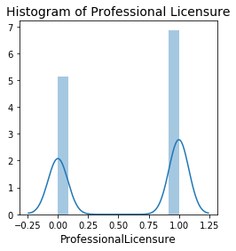

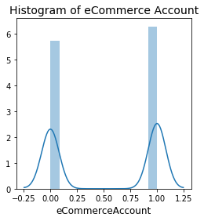

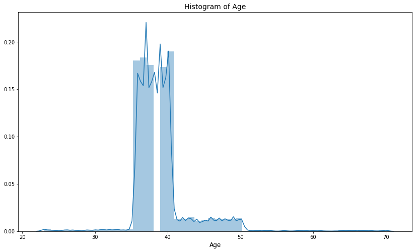

```python
#Checking the distributions of the ProfessionalLicensure variable
plt.figure(figsize = (4,4))
b = sns.distplot(df_train['ProfessionalLicensure'])
b.set_title('Histogram of Professional Licensure',fontsize = 14)
b.set_xlabel("ProfessionalLicensure",fontsize=12)
plt.show()

#Checking the distributions of the eCommerceAccount variable
plt.figure(figsize = (4,4))
b = sns.distplot(df_train['eCommerceAccount'])
b.set_title('Histogram of eCommerce Account',fontsize = 14)
b.set_xlabel("eCommerceAccount",fontsize=12)
plt.show()

#Checking the distributions of the Age variable
plt.figure(figsize = (14,8))
b = sns.distplot(df_train['Age'])
b.set_title('Histogram of Age',fontsize = 14)
b.set_xlabel("Age",fontsize=12)
plt.show()
```

The age distribution shows us that the majority of the customers are in between 35 and 45.

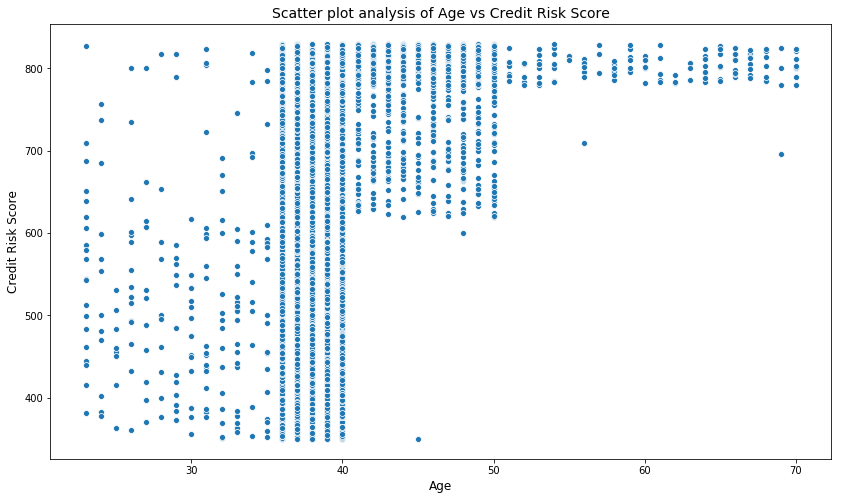

```python
#Checking the distributions of the Age variable
plt.figure(figsize = (14,8))
b = sns.scatterplot(df_train['Age'], train['CreditRiskScore'])
b.set_title('Scatter plot analysis of Age vs Credit Risk Score',fontsize = 14)
b.set_xlabel("Age",fontsize=12)
b.set_ylabel("Credit Risk Score", fontsize = 12)
plt.show()
```

This visualisation Age vs Credit Score shows us that with increase in Age Credit score is increased. Although, Credit Score evaluation gives more weightage to Credit History rather than Age. So this visualization doesn't give us the full picture.

#### Preprocessing on Train Payment Hisory Dataset

#### Checking for NaN Null values in the datasets

```python
print('Nulls in train_paymenthistory Data \n', train_paymenthistory.isna().sum())

print('Nulls in train_paymenthistory Data \n', train_paymenthistory.isnull().sum())
```

```
Nulls in train_paymenthistory Data
 CustomerID                                0
Current_Instalment_Sequence               0
Starting_Instalment                       0
Maturity_Period                           0
Current_Outstanding                       0
Current_Loan_to_Appraisedvalu_Percent     0
CurrentInterestrate                       0
RealEstate_Current_Inflation              0
GDP                                       0
UnemploymentRate                          0
Asset_type                                0
Urban_Development                         0
Villa_House                               0
Investment_SelfOccupied                   0
Starting_outstanding                      0
Starting_Loan_to_Appraisedvalu_Percent    0
StartingInterestrate                      0
RealEstate_Starting_Inflation             0
Payment_Status                            0
dtype: int64
Nulls in train_paymenthistory Data
 CustomerID                                0
Current_Instalment_Sequence               0
Starting_Instalment                       0
Maturity_Period                           0
Current_Outstanding                       0
Current_Loan_to_Appraisedvalu_Percent     0
CurrentInterestrate                       0
RealEstate_Current_Inflation              0
GDP                                       0
UnemploymentRate                          0
Asset_type                                0
Urban_Development                         0
Villa_House                               0
Investment_SelfOccupied                   0
Starting_outstanding                      0
Starting_Loan_to_Appraisedvalu_Percent    0
StartingInterestrate                      0
RealEstate_Starting_Inflation             0
Payment_Status                            0
dtype: int64
```

There are no 'NaN' or "Null" values in the dataset

```python
train_paymenthistory.head()
```

|  | CustomerID | Current_Instalment_Sequence | Starting_Instalment | Maturity_Period | Current_Outstanding | Current_Loan_to_Appraisedvalu_Percent | CurrentInterestrate | RealEstate_Current_Inflation | GDP | UnemploymentRate | Asset_type | Urban_Development | Villa_House | Investment_SelfOccupied | Starting_outstanding | Starting_Loan_to_Appraisedvalu_Percent | StartingInterestrate | RealEstate_Starting_Inflation | Payment_Status |
| --- | --- | --- | --- | --- | --- | --- | --- | --- | --- | --- | --- | --- | --- | --- | --- | --- | --- | --- | --- |
| 0 | C12116 | 25 | 25 | 113 | 41303.42 | 24.498336 | 9.2 | 2.2629 | 2.899137 | 4.7 | No shred services | No | Yes | Self Occupancy | 45000.0 | 69.4 | 9.2 | 0.8703 | Non-Payoff/Non-Default |
| 1 | C12116 | 26 | 25 | 113 | 41061.95 | 24.483867 | 9.2 | 2.2510 | 2.151365 | 4.7 | No shred services | No | Yes | Self Occupancy | 45000.0 | 69.4 | 9.2 | 0.8703 | Non-Payoff/Non-Default |
| 2 | C12116 | 27 | 25 | 113 | 40804.42 | 24.626795 | 9.2 | 2.2239 | 2.361722 | 4.4 | No shred services | No | Yes | Self Occupancy | 45000.0 | 69.4 | 9.2 | 0.8703 | Non-Payoff/Non-Default |
| 3 | C12116 | 28 | 25 | 113 | 40483.89 | 24.735883 | 9.2 | 2.1967 | 1.229172 | 4.6 | No shred services | No | Yes | Self Occupancy | 45000.0 | 69.4 | 9.2 | 0.8703 | Non-Payoff/Non-Default |
| 4 | C12116 | 29 | 25 | 113 | 40367.06 | 24.925476 | 9.2 | 2.1737 | 1.692969 | 4.5 | No shred services | No | Yes | Self Occupancy | 45000.0 | 69.4 | 9.2 | 0.8703 | Non-Payoff/Non-Default |

##### Dropping duplicates (If any)

```python
print(train_paymenthistory.shape)
train_paymenthistory.drop_duplicates(inplace = True)
print(train_paymenthistory.shape)
```

```
(269552, 19)
(269552, 19)
```

##### Rearranging Columns

```python
train_paymenthistory = train_paymenthistory[['CustomerID',
                                             'Maturity_Period',
                                             'Starting_Instalment',
                                             'Current_Instalment_Sequence',
                                             'Starting_outstanding',
                                             'Current_Outstanding',
                                             'Starting_Loan_to_Appraisedvalu_Percent',
                                             'Current_Loan_to_Appraisedvalu_Percent',
                                             'StartingInterestrate',
                                             'CurrentInterestrate',
                                             'RealEstate_Starting_Inflation',
                                             'RealEstate_Current_Inflation',
                                             'GDP',
                                             'UnemploymentRate',
                                             'Asset_type',
                                             'Urban_Development',
                                             'Villa_House',
                                             'Investment_SelfOccupied',
                                             'Payment_Status']]
```

```python
train_paymenthistory.head()
```

|  | CustomerID | Maturity_Period | Starting_Instalment | Current_Instalment_Sequence | Starting_outstanding | Current_Outstanding | Starting_Loan_to_Appraisedvalu_Percent | Current_Loan_to_Appraisedvalu_Percent | StartingInterestrate | CurrentInterestrate | RealEstate_Starting_Inflation | RealEstate_Current_Inflation | GDP | UnemploymentRate | Asset_type | Urban_Development | Villa_House | Investment_SelfOccupied | Payment_Status |
| --- | --- | --- | --- | --- | --- | --- | --- | --- | --- | --- | --- | --- | --- | --- | --- | --- | --- | --- | --- |
| 0 | C12116 | 113 | 25 | 25 | 45000.0 | 41303.42 | 69.4 | 24.498336 | 9.2 | 9.2 | 0.8703 | 2.2629 | 2.899137 | 4.7 | No shred services | No | Yes | Self Occupancy | Non-Payoff/Non-Default |
| 1 | C12116 | 113 | 25 | 26 | 45000.0 | 41061.95 | 69.4 | 24.483867 | 9.2 | 9.2 | 0.8703 | 2.2510 | 2.151365 | 4.7 | No shred services | No | Yes | Self Occupancy | Non-Payoff/Non-Default |
| 2 | C12116 | 113 | 25 | 27 | 45000.0 | 40804.42 | 69.4 | 24.626795 | 9.2 | 9.2 | 0.8703 | 2.2239 | 2.361722 | 4.4 | No shred services | No | Yes | Self Occupancy | Non-Payoff/Non-Default |
| 3 | C12116 | 113 | 25 | 28 | 45000.0 | 40483.89 | 69.4 | 24.735883 | 9.2 | 9.2 | 0.8703 | 2.1967 | 1.229172 | 4.6 | No shred services | No | Yes | Self Occupancy | Non-Payoff/Non-Default |
| 4 | C12116 | 113 | 25 | 29 | 45000.0 | 40367.06 | 69.4 | 24.925476 | 9.2 | 9.2 | 0.8703 | 2.1737 | 1.692969 | 4.5 | No shred services | No | Yes | Self Occupancy | Non-Payoff/Non-Default |

#### Feature Engineering on Train Payment History Dataset

##### Mean of the following Market and Bank Factors / columns group by Customer ID

1. Starting Outstanding
2. Starting_Loan_to_Appraisedvalu_Percent
3. Starting Interest Rate
4. CurrentInterestrate
5. RealEstate_Starting_Inflation
6. RealEstate_Current_Inflation
7. GDP
8. UnemploymentRate

```python
df_TPH = train_paymenthistory.groupby('CustomerID', as_index=False)['Starting_outstanding',
                                                                    'Starting_Loan_to_Appraisedvalu_Percent',
                                                                    'StartingInterestrate',
                                                                    'CurrentInterestrate',
                                                                    'RealEstate_Starting_Inflation',
                                                                    'RealEstate_Current_Inflation',
                                                                    'GDP',
                                                                    'UnemploymentRate'].mean()
```

```python
df_TPH.head()
```

|  | CustomerID | Starting_outstanding | Starting_Loan_to_Appraisedvalu_Percent | StartingInterestrate | CurrentInterestrate | RealEstate_Starting_Inflation | RealEstate_Current_Inflation | GDP | UnemploymentRate |
| --- | --- | --- | --- | --- | --- | --- | --- | --- | --- |
| 0 | C12116 | 45000.0 | 69.4 | 9.20 | 9.200000 | 0.8703 | 1.766579 | 0.879284 | 7.241667 |
| 1 | C12117 | 164500.0 | 70.0 | 7.50 | 9.688000 | 1.8691 | 2.064210 | 1.608584 | 4.810000 |
| 2 | C12118 | 44000.0 | 52.5 | 13.00 | 13.010714 | 0.7778 | 1.766423 | 1.264322 | 7.162857 |
| 3 | C12119 | 34800.0 | 56.9 | 12.35 | 12.350000 | 0.7837 | 1.766423 | 1.264322 | 7.162857 |
| 4 | C12120 | 61600.0 | 64.3 | 9.25 | 8.525000 | 0.7812 | 1.766423 | 1.264322 | 7.162857 |

#### Creating New Column - Calculating Instalments Paid so far (Max value of Current Instalment Sequence)

```python
Installments_Paid = train_paymenthistory.groupby(['CustomerID'], as_index=False).agg({'Current_Instalment_Sequence':'max'})
```

```python
#Adding this columns to final train payment dataframe
df_TPH['Installments_Paid'] = Installments_Paid['Current_Instalment_Sequence']
```

#### Creating New Column Instalments Remaining (Total instalments - Max(Current Instalment Sequence))

```python
Installments_Remaining = train_paymenthistory.groupby(['CustomerID'], as_index=False).agg({'Maturity_Period':'max'})
```

```python
df_TPH.head()
```

|  | CustomerID | Starting_outstanding | Starting_Loan_to_Appraisedvalu_Percent | StartingInterestrate | CurrentInterestrate | RealEstate_Starting_Inflation | RealEstate_Current_Inflation | GDP | UnemploymentRate | Installments_Paid |
| --- | --- | --- | --- | --- | --- | --- | --- | --- | --- | --- |
| 0 | C12116 | 45000.0 | 69.4 | 9.20 | 9.200000 | 0.8703 | 1.766579 | 0.879284 | 7.241667 | 48 |
| 1 | C12117 | 164500.0 | 70.0 | 7.50 | 9.688000 | 1.8691 | 2.064210 | 1.608584 | 4.810000 | 34 |
| 2 | C12118 | 44000.0 | 52.5 | 13.00 | 13.010714 | 0.7778 | 1.766423 | 1.264322 | 7.162857 | 60 |
| 3 | C12119 | 34800.0 | 56.9 | 12.35 | 12.350000 | 0.7837 | 1.766423 | 1.264322 | 7.162857 | 60 |
| 4 | C12120 | 61600.0 | 64.3 | 9.25 | 8.525000 | 0.7812 | 1.766423 | 1.264322 | 7.162857 | 60 |

```python
#Creating new column "Remaining_Intallments" are getting the value from difference of maturity period and installments paid
df_TPH['Remaining_Intallments'] = Installments_Remaining['Maturity_Period'] - df_TPH['Installments_Paid']
```

```python
#Adding maturity period column to final Train paymment history dataframe
df_TPH['MaturityPeriod'] = Installments_Remaining['Maturity_Period']
```

#### Creating New Column Current Outstanding (Minimum values of Current Outstanding)

```python
Current_Outstanding = train_paymenthistory.groupby(['CustomerID'], as_index=False).agg({'Current_Outstanding':'min'})
```

```python
df_TPH['Remaining_outstanding'] = Current_Outstanding['Current_Outstanding']
```

```python
df_TPH.head()
```

|  | CustomerID | Starting_outstanding | Starting_Loan_to_Appraisedvalu_Percent | StartingInterestrate | CurrentInterestrate | RealEstate_Starting_Inflation | RealEstate_Current_Inflation | GDP | UnemploymentRate | Installments_Paid | Remaining_Intallments | MaturityPeriod | Remaining_outstanding |
| --- | --- | --- | --- | --- | --- | --- | --- | --- | --- | --- | --- | --- | --- |
| 0 | C12116 | 45000.0 | 69.4 | 9.20 | 9.200000 | 0.8703 | 1.766579 | 0.879284 | 7.241667 | 48 | 65 | 113 | 29087.21 |
| 1 | C12117 | 164500.0 | 70.0 | 7.50 | 9.688000 | 1.8691 | 2.064210 | 1.608584 | 4.810000 | 34 | 104 | 138 | 160044.34 |
| 2 | C12118 | 44000.0 | 52.5 | 13.00 | 13.010714 | 0.7778 | 1.766423 | 1.264322 | 7.162857 | 60 | 45 | 105 | 34562.30 |
| 3 | C12119 | 34800.0 | 56.9 | 12.35 | 12.350000 | 0.7837 | 1.766423 | 1.264322 | 7.162857 | 60 | 46 | 106 | 27355.73 |
| 4 | C12120 | 61600.0 | 64.3 | 9.25 | 8.525000 | 0.7812 | 1.766423 | 1.264322 | 7.162857 | 60 | 47 | 107 | 43102.83 |

##### Creating New Column Average EMI (Average(Max(Current_Outstanding - Min(Current_Outstanding)))

```python
#Maximum value of Current_Outstanding for each customer
Max_Current_Outstanding = train_paymenthistory.groupby(['CustomerID'], as_index=False).agg({'Current_Outstanding':'max'})

#Minimum value of Current_Outstanding for each customer
Min_Current_Outstanding = train_paymenthistory.groupby(['CustomerID'], as_index=False).agg({'Current_Outstanding':'min'})

#Count of installments of Current_Outstanding for each customer
Count_Current_Outstanding = train_paymenthistory.groupby(['CustomerID'], as_index=False).agg({'Current_Outstanding':'count'})

#Calculating Average EMI, Difference of Max value minus min value of Current Outstanding divived by Couont of Current Outstanding minus 1
df_TPH['Average_EMI'] = (Max_Current_Outstanding['Current_Outstanding'] - Min_Current_Outstanding['Current_Outstanding'])/(Count_Current_Outstanding['Current_Outstanding']-1)
```

```python
df_TPH.head()
```

|  | CustomerID | Starting_outstanding | Starting_Loan_to_Appraisedvalu_Percent | StartingInterestrate | CurrentInterestrate | RealEstate_Starting_Inflation | RealEstate_Current_Inflation | GDP | UnemploymentRate | Installments_Paid | Remaining_Intallments | MaturityPeriod | Remaining_outstanding | Average_EMI |
| --- | --- | --- | --- | --- | --- | --- | --- | --- | --- | --- | --- | --- | --- | --- |
| 0 | C12116 | 45000.0 | 69.4 | 9.20 | 9.200000 | 0.8703 | 1.766579 | 0.879284 | 7.241667 | 48 | 65 | 113 | 29087.21 | 531.139565 |
| 1 | C12117 | 164500.0 | 70.0 | 7.50 | 9.688000 | 1.8691 | 2.064210 | 1.608584 | 4.810000 | 34 | 104 | 138 | 160044.34 | 267.554444 |
| 2 | C12118 | 44000.0 | 52.5 | 13.00 | 13.010714 | 0.7778 | 1.766423 | 1.264322 | 7.162857 | 60 | 45 | 105 | 34562.30 | 211.118235 |
| 3 | C12119 | 34800.0 | 56.9 | 12.35 | 12.350000 | 0.7837 | 1.766423 | 1.264322 | 7.162857 | 60 | 46 | 106 | 27355.73 | 161.588529 |
| 4 | C12120 | 61600.0 | 64.3 | 9.25 | 8.525000 | 0.7812 | 1.766423 | 1.264322 | 7.162857 | 60 | 47 | 107 | 43102.83 | 389.036471 |

#### Creating New column - Current Loan to Appraisal Value (Average Value)

```python
Average_Current_LTAV = train_paymenthistory.groupby(['CustomerID'], as_index=False).agg({'Current_Loan_to_Appraisedvalu_Percent':'mean'})
```

```python
df_TPH['Average_Current_LTAV'] = Average_Current_LTAV['Current_Loan_to_Appraisedvalu_Percent']
```

#### Creating 3 New Columns from Payment Status - Count of each payment type for each customer

```python
payment_values = train_paymenthistory.groupby(['CustomerID', 'Payment_Status']).size().reset_index(name = 'count')
```

```python
payment_values.head()
```

|  | CustomerID | Payment_Status | count |
| --- | --- | --- | --- |
| 0 | C12116 | Default | 1 |
| 1 | C12116 | Non-Payoff/Non-Default | 23 |
| 2 | C12117 | Default | 1 |
| 3 | C12117 | Non-Payoff/Non-Default | 9 |
| 4 | C12118 | Non-Payoff/Non-Default | 35 |

```python
from pandas import *
payment_new_cols = pivot_table(payment_values, values = 'count', index = ['CustomerID'], columns = ['Payment_Status'],
                               aggfunc = np.sum, fill_value = '0').astype('int')
```

```python
payment_new_cols.head()
```

| Payment_Status CustomerID | Default | Non-Payoff/Non-Default | Payoff |
| --- | --- | --- | --- |
| C12116 | 1 | 23 | 0 |
| C12117 | 1 | 9 | 0 |
| C12118 | 0 | 35 | 0 |
| C12119 | 0 | 35 | 0 |
| C12120 | 0 | 35 | 0 |

```python
#Merging the payment_new_Cols with df_TPH as saving as df_TPH
df_TPH = pd.merge(df_TPH, payment_new_cols, on='CustomerID')
```

```python
df_TPH.head()
```

|  | CustomerID | Starting_outstanding | Starting_Loan_to_Appraisedvalu_Percent | StartingInterestrate | CurrentInterestrate | RealEstate_Starting_Inflation | RealEstate_Current_Inflation | GDP | UnemploymentRate | Installments_Paid | Remaining_Intallments | MaturityPeriod | Remaining_outstanding | Average_EMI | Average_Current_LTAV | Default | Non-Payoff/Non-Default | Payoff |
| --- | --- | --- | --- | --- | --- | --- | --- | --- | --- | --- | --- | --- | --- | --- | --- | --- | --- | --- |
| 0 | C12116 | 45000.0 | 69.4 | 9.20 | 9.200000 | 0.8703 | 1.766579 | 0.879284 | 7.241667 | 48 | 65 | 113 | 29087.21 | 531.139565 | 26.319186 | 1 | 23 | 0 |
| 1 | C12117 | 164500.0 | 70.0 | 7.50 | 9.688000 | 1.8691 | 2.064210 | 1.608584 | 4.810000 | 34 | 104 | 138 | 160044.34 | 267.554444 | 62.596432 | 1 | 9 | 0 |
| 2 | C12118 | 44000.0 | 52.5 | 13.00 | 13.010714 | 0.7778 | 1.766423 | 1.264322 | 7.162857 | 60 | 45 | 105 | 34562.30 | 211.118235 | 20.842982 | 0 | 35 | 0 |
| 3 | C12119 | 34800.0 | 56.9 | 12.35 | 12.350000 | 0.7837 | 1.766423 | 1.264322 | 7.162857 | 60 | 46 | 106 | 27355.73 | 161.588529 | 22.557807 | 0 | 35 | 0 |
| 4 | C12120 | 61600.0 | 64.3 | 9.25 | 8.525000 | 0.7812 | 1.766423 | 1.264322 | 7.162857 | 60 | 47 | 107 | 43102.83 | 389.036471 | 23.836162 | 0 | 35 | 0 |

##### Adding Remaining columns from Train Payment History dataset to df_TPH

```python
#Creating a list of remaining columns
Remaining_Cols = ['CustomerID','Asset_type', 'Urban_Development', 'Villa_House','Investment_SelfOccupied']
#Creating a new dataframe with the remaining columns
df_Remaining_Cols= train_paymenthistory[Remaining_Cols]
#Dropping all the duplicated
df_Remaining_Cols.drop_duplicates(inplace=True)
print(df_Remaining_Cols.shape)
```

```
(11093, 5)
```

```python
#Merging the Remaining columns dataframe with df_TPH and saving as df_TPH
df_TPH = pd.merge(df_TPH, df_Remaining_Cols, on='CustomerID')
```

```python
print(df_TPH.shape)
print(df_Remaining_Cols.shape)
print(df_TPH.shape)
df_TPH.head()
```

```
(11093, 22)
(11093, 5)
(11093, 22)
```

|  | CustomerID | Starting_outstanding | Starting_Loan_to_Appraisedvalu_Percent | StartingInterestrate | CurrentInterestrate | RealEstate_Starting_Inflation | RealEstate_Current_Inflation | GDP | UnemploymentRate | Installments_Paid | ... | Remaining_outstanding | Average_EMI | Average_Current_LTAV | Default | Non-Payoff/Non-Default | Payoff | Asset_type | Urban_Development | Villa_House | Investment_SelfOccupied |
| --- | --- | --- | --- | --- | --- | --- | --- | --- | --- | --- | --- | --- | --- | --- | --- | --- | --- | --- | --- | --- | --- |
| 0 | C12116 | 45000.0 | 69.4 | 9.20 | 9.200000 | 0.8703 | 1.766579 | 0.879284 | 7.241667 | 48 | ... | 29087.21 | 531.139565 | 26.319186 | 1 | 23 | 0 | No shred services | No | Yes | Self Occupancy |
| 1 | C12117 | 164500.0 | 70.0 | 7.50 | 9.688000 | 1.8691 | 2.064210 | 1.608584 | 4.810000 | 34 | ... | 160044.34 | 267.554444 | 62.596432 | 1 | 9 | 0 | No shred services | No | Yes | Self Occupancy |
| 2 | C12118 | 44000.0 | 52.5 | 13.00 | 13.010714 | 0.7778 | 1.766423 | 1.264322 | 7.162857 | 60 | ... | 34562.30 | 211.118235 | 20.842982 | 0 | 35 | 0 | No shred services | No | Yes | Self Occupancy |
| 3 | C12119 | 34800.0 | 56.9 | 12.35 | 12.350000 | 0.7837 | 1.766423 | 1.264322 | 7.162857 | 60 | ... | 27355.73 | 161.588529 | 22.557807 | 0 | 35 | 0 | Complex With shared services | No | No | Self Occupancy |
| 4 | C12120 | 61600.0 | 64.3 | 9.25 | 8.525000 | 0.7812 | 1.766423 | 1.264322 | 7.162857 | 60 | ... | 43102.83 | 389.036471 | 23.836162 | 0 | 35 | 0 | No shred services | No | Yes | Self Occupancy |

5 rows × 22 columns

#### Merging All Dataframes after Preprocessing and Feature Engineering on both dataframes - Train(df_train) and Train Payment History (train_paymentHistory_df)

```python
#Merging with TRAIN Dataset
df_final = pd.merge(df_train, df_TPH, on='CustomerID')
```

```python
df_final.shape
```

```
(11093, 30)
```

#### Feature Engineering on combined dataset df_final

##### Creating New Column "Average Monthly Spending" by adding Utility and Average EMI and dividing with Salary

```python
df_final['Average_Monthly_Spending'] = (df_final['UtilitySpending'] + df_final['Average_EMI'])/df_final['Salary']
```

```python
df_final.head()
```

|  | CustomerID | Salary | ProfessionalLicensure | UtilitySpending | eCommerceAccount | SocialMediaAccount | NoOfProperties | CreditRiskScore | Age | Starting_outstanding | ... | Average_EMI | Average_Current_LTAV | Default | Non-Payoff/Non-Default | Payoff | Asset_type | Urban_Development | Villa_House | Investment_SelfOccupied | Average_Monthly_Spending |
| --- | --- | --- | --- | --- | --- | --- | --- | --- | --- | --- | --- | --- | --- | --- | --- | --- | --- | --- | --- | --- | --- |
| 0 | C12116 | 1238.006112 | 0 | 492.726433 | 1 | No | 2 | 711 | 50 | 45000.0 | ... | 531.139565 | 26.319186 | 1 | 23 | 0 | No shred services | No | Yes | Self Occupancy | 0.827028 |
| 1 | C12117 | 1633.000000 | 1 | 477.870359 | 1 | Yes | 1 | 767 | 38 | 164500.0 | ... | 267.554444 | 62.596432 | 1 | 9 | 0 | No shred services | No | Yes | Self Occupancy | 0.456476 |
| 2 | C12118 | 1489.000000 | 0 | 351.593736 | 1 | Yes | 1 | 827 | 49 | 44000.0 | ... | 211.118235 | 20.842982 | 0 | 35 | 0 | No shred services | No | Yes | Self Occupancy | 0.377913 |
| 3 | C12119 | 1241.000000 | 0 | 403.589993 | 1 | No | 1 | 795 | 43 | 34800.0 | ... | 161.588529 | 22.557807 | 0 | 35 | 0 | Complex With shared services | No | No | Self Occupancy | 0.455422 |
| 4 | C12120 | 1074.000000 | 1 | 406.066005 | 1 | No | 1 | 827 | 44 | 61600.0 | ... | 389.036471 | 23.836162 | 0 | 35 | 0 | No shred services | No | Yes | Self Occupancy | 0.740319 |

5 rows × 31 columns

```python
#Dropping Utility and Average_EMI column
df_final.drop(['UtilitySpending', 'Average_EMI'], axis = 1, inplace=True)
print(df_final.shape)
```

```
(11093, 29)
```

```python
df_final.head(1)
```

|  | CustomerID | Salary | ProfessionalLicensure | eCommerceAccount | SocialMediaAccount | NoOfProperties | CreditRiskScore | Age | Starting_outstanding | Starting_Loan_to_Appraisedvalu_Percent | ... | Remaining_outstanding | Average_Current_LTAV | Default | Non-Payoff/Non-Default | Payoff | Asset_type | Urban_Development | Villa_House | Investment_SelfOccupied | Average_Monthly_Spending |
| --- | --- | --- | --- | --- | --- | --- | --- | --- | --- | --- | --- | --- | --- | --- | --- | --- | --- | --- | --- | --- | --- |
| 0 | C12116 | 1238.006112 | 0 | 1 | No | 2 | 711 | 50 | 45000.0 | 69.4 | ... | 29087.21 | 26.319186 | 1 | 23 | 0 | No shred services | No | Yes | Self Occupancy | 0.827028 |

1 rows × 29 columns

##### Data Types Conversion

```python
#Creating a list of categorical columns
cat_col = ['ProfessionalLicensure', 'eCommerceAccount', 'SocialMediaAccount','Asset_type',
          'Urban_Development', 'Villa_House', 'Investment_SelfOccupied']
```

```python
#Converting the data type
df_final[cat_col] = df_final[cat_col].astype('category')
```

```python
df_final.head()
```

|  | CustomerID | Salary | ProfessionalLicensure | eCommerceAccount | SocialMediaAccount | NoOfProperties | CreditRiskScore | Age | Starting_outstanding | Starting_Loan_to_Appraisedvalu_Percent | ... | Remaining_outstanding | Average_Current_LTAV | Default | Non-Payoff/Non-Default | Payoff | Asset_type | Urban_Development | Villa_House | Investment_SelfOccupied | Average_Monthly_Spending |
| --- | --- | --- | --- | --- | --- | --- | --- | --- | --- | --- | --- | --- | --- | --- | --- | --- | --- | --- | --- | --- | --- |
| 0 | C12116 | 1238.006112 | 0 | 1 | No | 2 | 711 | 50 | 45000.0 | 69.4 | ... | 29087.21 | 26.319186 | 1 | 23 | 0 | No shred services | No | Yes | Self Occupancy | 0.827028 |
| 1 | C12117 | 1633.000000 | 1 | 1 | Yes | 1 | 767 | 38 | 164500.0 | 70.0 | ... | 160044.34 | 62.596432 | 1 | 9 | 0 | No shred services | No | Yes | Self Occupancy | 0.456476 |
| 2 | C12118 | 1489.000000 | 0 | 1 | Yes | 1 | 827 | 49 | 44000.0 | 52.5 | ... | 34562.30 | 20.842982 | 0 | 35 | 0 | No shred services | No | Yes | Self Occupancy | 0.377913 |
| 3 | C12119 | 1241.000000 | 0 | 1 | No | 1 | 795 | 43 | 34800.0 | 56.9 | ... | 27355.73 | 22.557807 | 0 | 35 | 0 | Complex With shared services | No | No | Self Occupancy | 0.455422 |
| 4 | C12120 | 1074.000000 | 1 | 1 | No | 1 | 827 | 44 | 61600.0 | 64.3 | ... | 43102.83 | 23.836162 | 0 | 35 | 0 | No shred services | No | Yes | Self Occupancy | 0.740319 |

5 rows × 29 columns

##### Checking and removing variables with correlation more than 95%

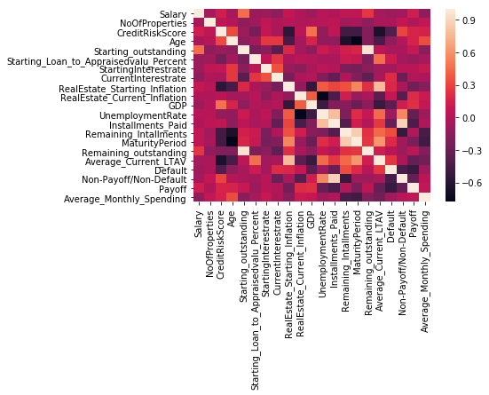

```python
correlation_df_final = df_final.corr()
sns.heatmap(correlation_df_final)
```

```python
#Creating a list of highly correlated variables
High_Corr_Cols = ['Starting_outstanding', 'Non-Payoff/Non-Default']

#Dropping variables with high correlation
df_final.drop(High_Corr_Cols, axis = 1, inplace=True)
print(df_final.shape)
```

```
(11093, 27)
```

```python
df_final.head()
```

|  | CustomerID | Salary | ProfessionalLicensure | eCommerceAccount | SocialMediaAccount | NoOfProperties | CreditRiskScore | Age | Starting_Loan_to_Appraisedvalu_Percent | StartingInterestrate | ... | MaturityPeriod | Remaining_outstanding | Average_Current_LTAV | Default | Payoff | Asset_type | Urban_Development | Villa_House | Investment_SelfOccupied | Average_Monthly_Spending |
| --- | --- | --- | --- | --- | --- | --- | --- | --- | --- | --- | --- | --- | --- | --- | --- | --- | --- | --- | --- | --- | --- |
| 0 | C12116 | 1238.006112 | 0 | 1 | No | 2 | 711 | 50 | 69.4 | 9.20 | ... | 113 | 29087.21 | 26.319186 | 1 | 0 | No shred services | No | Yes | Self Occupancy | 0.827028 |
| 1 | C12117 | 1633.000000 | 1 | 1 | Yes | 1 | 767 | 38 | 70.0 | 7.50 | ... | 138 | 160044.34 | 62.596432 | 1 | 0 | No shred services | No | Yes | Self Occupancy | 0.456476 |
| 2 | C12118 | 1489.000000 | 0 | 1 | Yes | 1 | 827 | 49 | 52.5 | 13.00 | ... | 105 | 34562.30 | 20.842982 | 0 | 0 | No shred services | No | Yes | Self Occupancy | 0.377913 |
| 3 | C12119 | 1241.000000 | 0 | 1 | No | 1 | 795 | 43 | 56.9 | 12.35 | ... | 106 | 27355.73 | 22.557807 | 0 | 0 | Complex With shared services | No | No | Self Occupancy | 0.455422 |
| 4 | C12120 | 1074.000000 | 1 | 1 | No | 1 | 827 | 44 | 64.3 | 9.25 | ... | 107 | 43102.83 | 23.836162 | 0 | 0 | No shred services | No | Yes | Self Occupancy | 0.740319 |

5 rows × 27 columns

# Visualizations

##### Outlier Analysis of the Target Variable

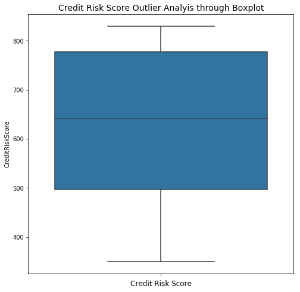

```
There are no outliers in the Target Variable
```

```python
plt.figure(figsize = (8,8))
sns.boxplot(df_final.CreditRiskScore, orient = 'v')
plt.title('Credit Risk Score Outlier Analyis through Boxplot', fontsize = 14)
plt.xlabel('Credit Risk Score', fontsize = 12)
plt.show()

print("There are no outliers in the Target Variable")
```

##### Analysing the distribution of the Target Variable

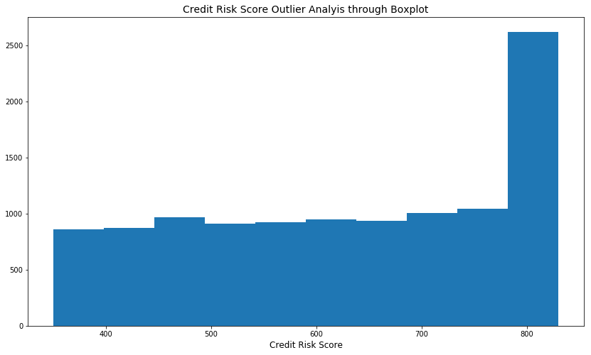

```
The target variable is negatively skewed to the left
```

```python
plt.figure(figsize=(14,8))
plt.hist(df_final.CreditRiskScore)
plt.title('Credit Risk Score Outlier Analyis through Boxplot', fontsize = 14)
plt.xlabel('Credit Risk Score', fontsize = 12)
plt.show()

print("The target variable is negatively skewed to the left")
```

##### Analysing Macro Factors GDP, Unemployment rate, Real Estate Inflation

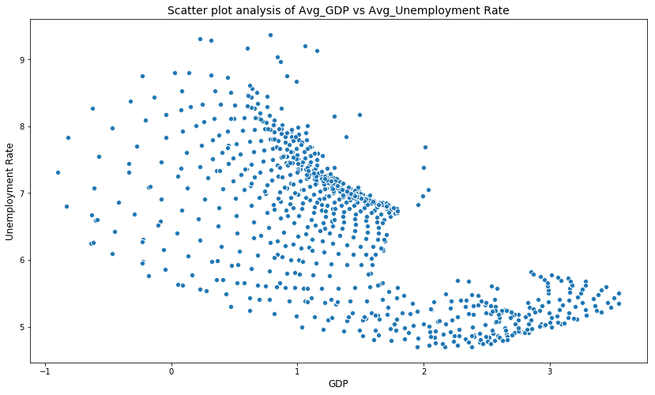

```
In the preprocessing of the data we have take the average of GDP and Unemployment Rate. As the general statistic is that GPD and Unemployment rate are inversely proportional to each other. So as GPD increases Unemployment rate tend to decrease.
```

```python
#As GDP is the major macro factor we analyse it with reference to the other two variables
plt.figure(figsize = (14,8))
b = sns.scatterplot(df_final['GDP'], df_final['UnemploymentRate'])
b.set_title('Scatter plot analysis of Avg_GDP vs Avg_Unemployment Rate',fontsize = 14)
b.set_xlabel("GDP",fontsize=12)
b.set_ylabel("Unemployment Rate", fontsize = 12)
plt.show()

print("In the preprocessing of the data we have take the average of GDP and Unemployment Rate. As the general statistic is that GPD and Unemployment rate are inversely proportional to each other. So as GPD increases Unemployment rate tend to decrease. ")
```

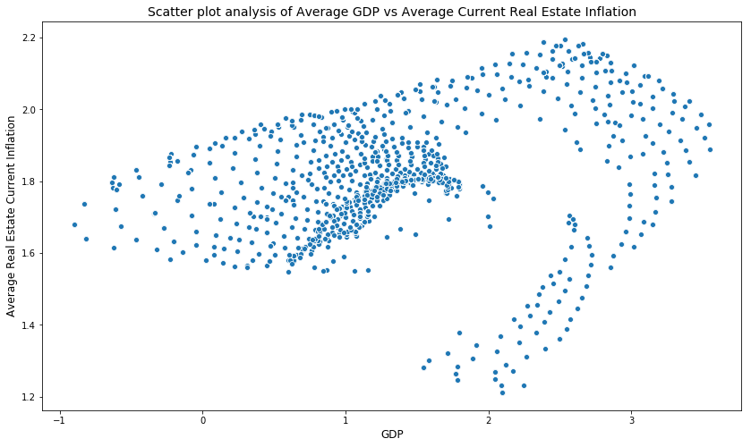

[output not shown]

```python
#Average GDP vs Average Realestate Current inflation
plt.figure(figsize = (14,8))
b = sns.scatterplot(df_final['GDP'], df_final['RealEstate_Current_Inflation'])
b.set_title('Scatter plot analysis of Average GDP vs Average Current Real Estate Inflation',fontsize = 14)
b.set_xlabel("GDP",fontsize=12)
b.set_ylabel("Average Real Estate Current Inflation", fontsize = 12)
plt.show()
print("This visualization shows us that as Average GDP increases Average Real Estate inflation is increasing")
```

##### Salary Distribution Analysis

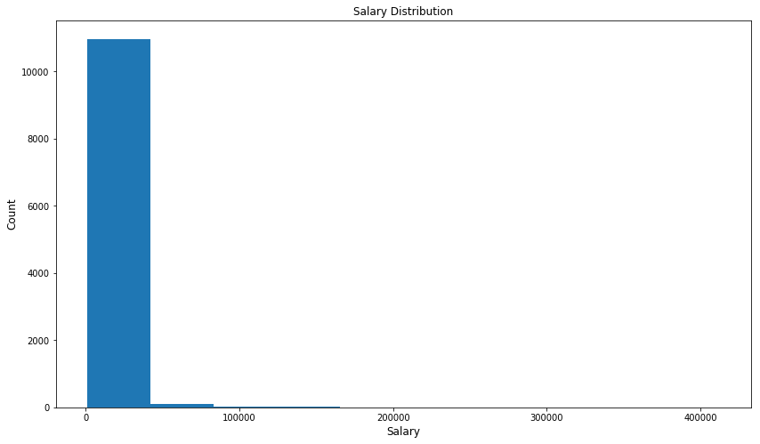

```python
#Checking the distributions of the Age variable
plt.figure(figsize = (14,8))

plt.hist(df_final['Salary'])
plt.title('Salary Distribution')
plt.xlabel("Salary",fontsize=12)
plt.ylabel("Count", fontsize = 12)
plt.show()
```

##### Analysis of Salary vs Credit Risk Score

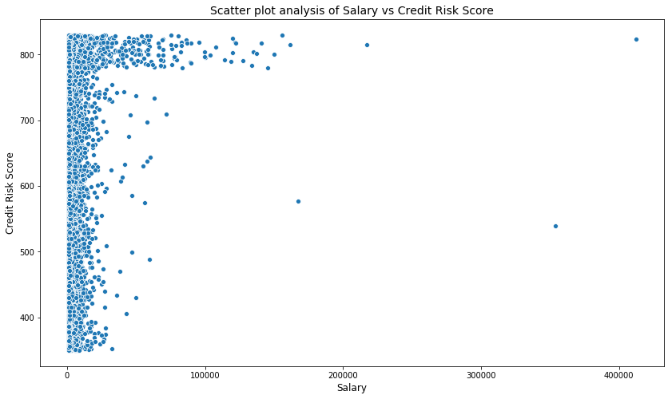

```python
#Analysing salary vs Credit Risk Score
plt.figure(figsize = (14,8))
b = sns.scatterplot(df_final['Salary'], df_final['CreditRiskScore'])
b.set_title('Scatter plot analysis of Salary vs Credit Risk Score',fontsize = 14)
b.set_xlabel("Salary",fontsize=12)
b.set_ylabel("Credit Risk Score", fontsize = 12)
plt.show()
```

##### Analysis of Installment Status for each Customer vs Salary

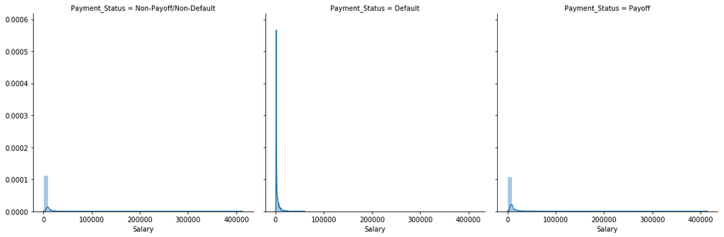

```python
g = sns.FacetGrid(df_all,col='Payment_Status', height = 5, aspect= 1)
g.map(sns.distplot,'Salary')
plt.show()
```

##### Analysing the relation between Salary and spending (Utility spendin and EMI)

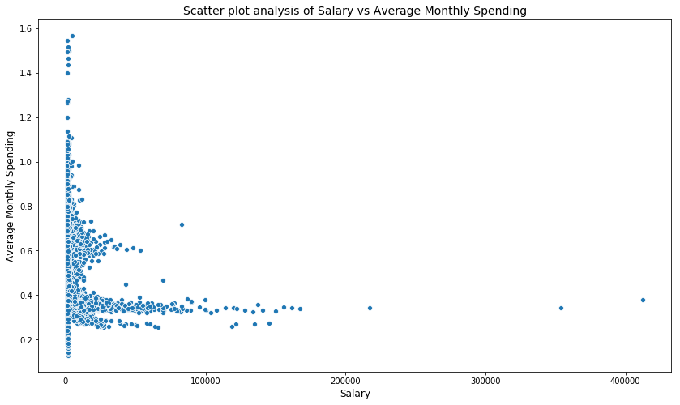

```python
plt.figure(figsize = (14,8))
b = sns.scatterplot(df_final['Salary'], df_final['Average_Monthly_Spending'])
b.set_title('Scatter plot analysis of Salary vs Average Monthly Spending',fontsize = 14)
b.set_xlabel("Salary",fontsize=12)
b.set_ylabel("Average Monthly Spending", fontsize = 12)
plt.show()
```

##### Analysis of Credit History vs Credit Risk Score

```python
plt.figure(figsize = (14,8))
b = sns.scatterplot(df_train['Installments_Paid'], train['CreditRiskScore'])
b.set_title('Scatter plot analysis of Installments_Paid vs Credit Risk Score',fontsize = 14)
b.set_xlabel("Installments_Paid",fontsize=12)
b.set_ylabel("Credit Risk Score", fontsize = 12)
plt.show()
```

[output not shown]

##### Analysing the Age distribution

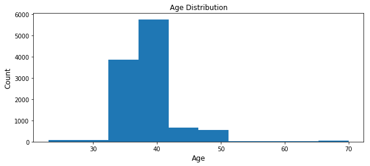

```python
#Checking the distributions of the Age variable
plt.figure(figsize = (10,4))
plt.hist(df_final['Age'])
plt.title('Age Distribution')
plt.xlabel("Age",fontsize=12)
plt.ylabel("Count", fontsize = 12)
plt.show()
```

##### Analysis of Age vs Credit Risk Score

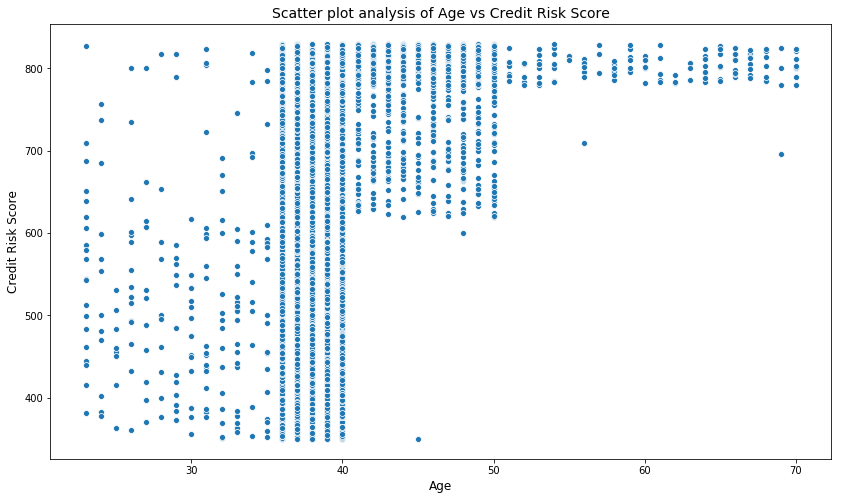

```python
#Checking the distributions of the Age variable
plt.figure(figsize = (14,8))
b = sns.scatterplot(df_train['Age'], train['CreditRiskScore'])
b.set_title('Scatter plot analysis of Age vs Credit Risk Score',fontsize = 14)
b.set_xlabel("Age",fontsize=12)
b.set_ylabel("Credit Risk Score", fontsize = 12)
plt.show()
```

##### Analysing the relation between age, credit history and credit score

```python
#Visualizing age in buckets
#Binning Age
df_final['Age_Bins'] = np.digitize(df_final.Age,[0,15,30,45,60,75],right=True)
```

```python
#Binning Credit History, from months to years.
df_final['Credit_History_Bins'] = np.digitize(df_final.Installments_Paid,[0,12,24,36,48,60],right=True)
#Grouping data by Age_Bins and Credit History BIns / Installments Paid
age_credithistory = df_final.groupby(['Age_Bins','Credit_History_Bins']).size().unstack().reset_index().set_index('Age_Bins')
```

[figure not shown]

```python
#Visualising the data
age_credithistory.plot(kind= 'bar',title = 'Age Bins and Credit History Bins', figsize=(14,8))
plt.xticks([0,1,2, 3],["<15","15-30", "30-45", "45-60"],rotation = 0)
plt.show()
```

##### Analysis of Age and Credit Risk Score

```python
age_creditRiskScore = df_final.groupby(['CreditRiskScore', 'Age_Bins']).size().unstack().reset_index().set_index('CreditRiskScore')
```

[output not shown]

[figure not shown]

```python
#Visualising the data
age_creditRiskScore.plot(kind= 'bar',title = 'Age Bins and Credit Credit Risk Score', figsize=(16,8))
plt.xticks([0,1,2, 3],["<15","15-30", "30-45", "45-60"],rotation = 0)
print("AGE BIN 2", "15 - 30 Years" )
print("AGE BIN 3", "30 - 45 Years" )
print("AGE BIN 4", "45 - 60 Years" )
print("AGE BIN 5", "Above 60 Years" )
plt.show()
```

##### Analysis any relation between Urban Development, Villa House with Current Loan Appraised Value

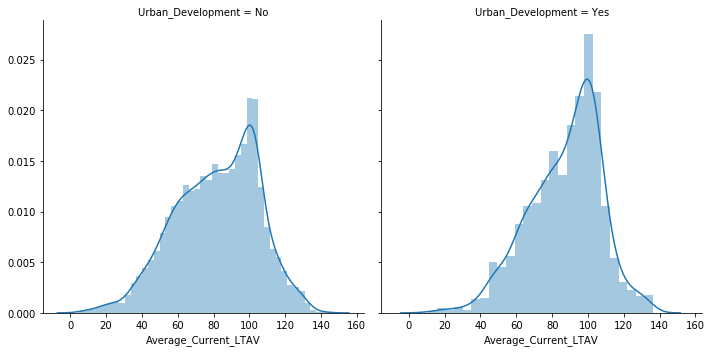

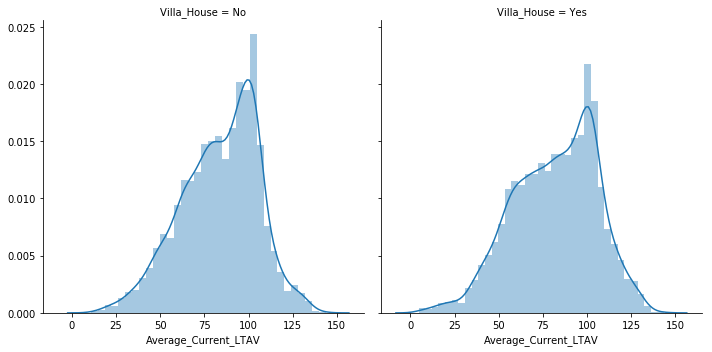

```python
g = sns.FacetGrid(df_final,col='Urban_Development',height = 5)
g.map(sns.distplot,'Average_Current_LTAV')
plt.show()


g = sns.FacetGrid(df_final,col='Villa_House',height = 5)
g.map(sns.distplot,'Average_Current_LTAV')
plt.show()
```

##### Analysis of Credit Risk Score with No of Properties

[figure not shown]

```python
#Checking the distributions of the Age variable
plt.figure(figsize = (14,8))
plt.barh(df_train['CreditRiskScore'], df_train['NoOfProperties'])
plt.title('Credit Risk Score vs No of Properties')
plt.xlabel("Credit Risk Score",fontsize=12)
plt.ylabel("No of Properties", fontsize = 12)
plt.show()
```

## MODEL BUILDING

```python
#Droppinng the CustomerID column and saving it as "df_final"
df_model = df_final.drop('CustomerID', axis =1)
```

```python
#Dummification of the dataframe Categorical columns
df_model = pd.get_dummies(df_model)
print(df_model.shape)
```

```
(11093, 35)
```

```python
#Splitting the dataframe "df_model" and Creating features and label
X = df_model.drop(['CreditRiskScore'], axis = 1)
y = df_model['CreditRiskScore']
```

```python
df_model.head()
```

|  | Salary | NoOfProperties | CreditRiskScore | Age | Starting_Loan_to_Appraisedvalu_Percent | StartingInterestrate | CurrentInterestrate | RealEstate_Starting_Inflation | RealEstate_Current_Inflation | GDP | ... | SocialMediaAccount_No | SocialMediaAccount_Yes | Asset_type_Complex With shared services | Asset_type_No shred services | Urban_Development_No | Urban_Development_Yes | Villa_House_No | Villa_House_Yes | Investment_SelfOccupied_Investment | Investment_SelfOccupied_Self Occupancy |
| --- | --- | --- | --- | --- | --- | --- | --- | --- | --- | --- | --- | --- | --- | --- | --- | --- | --- | --- | --- | --- | --- |
| 0 | 1238.006112 | 2 | 711 | 50 | 69.4 | 9.20 | 9.200000 | 0.8703 | 1.766579 | 0.879284 | ... | 1 | 0 | 0 | 1 | 1 | 0 | 0 | 1 | 0 | 1 |
| 1 | 1633.000000 | 1 | 767 | 38 | 70.0 | 7.50 | 9.688000 | 1.8691 | 2.064210 | 1.608584 | ... | 0 | 1 | 0 | 1 | 1 | 0 | 0 | 1 | 0 | 1 |
| 2 | 1489.000000 | 1 | 827 | 49 | 52.5 | 13.00 | 13.010714 | 0.7778 | 1.766423 | 1.264322 | ... | 0 | 1 | 0 | 1 | 1 | 0 | 0 | 1 | 0 | 1 |
| 3 | 1241.000000 | 1 | 795 | 43 | 56.9 | 12.35 | 12.350000 | 0.7837 | 1.766423 | 1.264322 | ... | 1 | 0 | 1 | 0 | 1 | 0 | 1 | 0 | 0 | 1 |
| 4 | 1074.000000 | 1 | 827 | 44 | 64.3 | 9.25 | 8.525000 | 0.7812 | 1.766423 | 1.264322 | ... | 1 | 0 | 0 | 1 | 1 | 0 | 0 | 1 | 0 | 1 |

5 rows × 35 columns

### Linear Regression

```python
#Splitting the data
X_train, X_test, y_train, y_test = train_test_split(X, y, test_size=0.15, random_state=101)
```

```python
from sklearn.linear_model import LinearRegression
lm = LinearRegression()
lm.fit(X_train,y_train)
```

```
LinearRegression(copy_X=True, fit_intercept=True, n_jobs=None,
         normalize=False)
```

```python
# print the intercept
print(lm.intercept_)
```

```
1327.7751759266707
```

```python
coeff_df = pd.DataFrame(lm.coef_,X.columns,columns=['Coefficient'])
coeff_df
```

|  | Coefficient |
| --- | --- |
| Salary | 0.001950 |
| NoOfProperties | -2.068395 |
| Age | -1.346899 |
| Starting_Loan_to_Appraisedvalu_Percent | 0.481553 |
| StartingInterestrate | -0.861118 |
| CurrentInterestrate | -2.247757 |
| RealEstate_Starting_Inflation | -11.757326 |
| RealEstate_Current_Inflation | -156.634208 |
| GDP | 38.732574 |
| UnemploymentRate | 8.758072 |
| Installments_Paid | -1.361234 |
| Remaining_Intallments | 0.260600 |
| MaturityPeriod | -1.100634 |
| Remaining_outstanding | -0.000069 |
| Average_Current_LTAV | -3.573741 |
| Default | -70.610208 |
| Payoff | -46.737238 |
| Average_Monthly_Spending | -34.880716 |
| Age_Bins | -3.852422 |
| Credit_History_Bins | 24.194171 |
| ProfessionalLicensure_0 | 1.712020 |
| ProfessionalLicensure_1 | -1.712020 |
| eCommerceAccount_0 | 0.156531 |
| eCommerceAccount_1 | -0.156531 |
| SocialMediaAccount_No | -1.175308 |
| SocialMediaAccount_Yes | 1.175308 |
| Asset_type_Complex With shared services | -2.517643 |
| Asset_type_No shred services | 2.517643 |
| Urban_Development_No | 3.786860 |
| Urban_Development_Yes | -3.786860 |
| Villa_House_No | 0.324736 |
| Villa_House_Yes | -0.324736 |
| Investment_SelfOccupied_Investment | 7.857316 |
| Investment_SelfOccupied_Self Occupancy | -7.857316 |

```python
predictions = lm.predict(X_test)
```

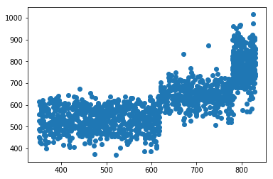

```python
plt.scatter(y_test,predictions)
```

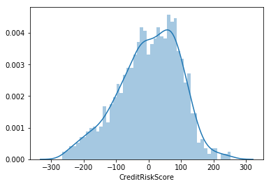

```python
#Residual Histogram
sns.distplot((y_test-predictions),bins=50);
```

```python
from sklearn import metrics
print('MAE:', metrics.mean_absolute_error(y_test, predictions))
print('MSE:', metrics.mean_squared_error(y_test, predictions))
print('RMSE:', np.sqrt(metrics.mean_squared_error(y_test, predictions)))
```

```
MAE: 76.56198934045895
MSE: 8915.926446313722
RMSE: 94.42418358828273
```

### Random Forest

```python
#Splitting the data
X_train, X_test, y_train, y_test = train_test_split(X, y, test_size=0.25, random_state=42)
```

```python
# Scale the data to be between -1 and 1
from sklearn.preprocessing import StandardScaler

scaler = StandardScaler()
scaler.fit(X_train)
X_train = scaler.transform(X_train)
X_test = scaler.transform(X_test)
```

```python
from sklearn.model_selection import GridSearchCV
from sklearn.ensemble import RandomForestRegressor
# Creating the parameter grid
param_grid = {
    'bootstrap': [True],
    'max_depth': [80, 90, 100, 110],
    'max_features': [2, 3],
    'min_samples_leaf': [3, 4, 5],
    'min_samples_split': [8, 10, 12],
    'n_estimators': [100, 200, 300]
}
# Create a based model
rf = RandomForestRegressor()
# Instantiate the grid search model
grid_search = GridSearchCV(estimator = rf, param_grid = param_grid,
                          cv = 5, n_jobs = -1, verbose = 2)
```

```python
# Fit the grid search to the data
grid_search.fit(X_train, y_train)
#Printing the beset parameters after grid search
grid_search.best_params_
```

```
Fitting 5 folds for each of 216 candidates, totalling 1080 fits
```

```
[Parallel(n_jobs=-1)]: Using backend LokyBackend with 4 concurrent workers.
[Parallel(n_jobs=-1)]: Done  33 tasks      | elapsed:   33.5s
[Parallel(n_jobs=-1)]: Done 154 tasks      | elapsed:  2.3min
[Parallel(n_jobs=-1)]: Done 357 tasks      | elapsed:  5.9min
[Parallel(n_jobs=-1)]: Done 640 tasks      | elapsed: 10.6min
[Parallel(n_jobs=-1)]: Done 1005 tasks      | elapsed: 16.9min
[Parallel(n_jobs=-1)]: Done 1080 out of 1080 | elapsed: 18.3min finished
```

```
{'bootstrap': True,
 'max_depth': 90,
 'max_features': 3,
 'min_samples_leaf': 3,
 'min_samples_split': 10,
 'n_estimators': 200}
```

```python
#Function to predict on the validation data and print the results for various metrics
def evaluate(model, test_features, test_labels):
    predictions = model.predict(test_features)
    errors = abs(predictions - test_labels)
    mape = 100 * np.mean(errors / test_labels)
    accuracy = 100 - mape
    print('Model Performance')
    print("RMSE", np.sqrt(metrics.mean_squared_error(predictions, test_labels)))
    print('Average Error: {:0.4f} degrees.'.format(np.mean(errors)))
    print('Accuracy = {:0.2f}%.'.format(accuracy))

    return accuracy
```

```python
from sklearn.model_selection import RandomizedSearchCV

#Predicting on validation data using the above defined function and best parameters of the grid search
best_grid = grid_search.best_estimator_
grid_accuracy = evaluate(best_grid, X_test, y_test)
```

```
Model Performance
RMSE 76.29349721558411
Average Error: 59.6920 degrees.
Accuracy = 88.80%.
```

```
Feature ranking:
1. feature 14 (0.193671)
2. feature 11 (0.108486)
3. feature 12 (0.103775)
4. feature 8 (0.077833)
5. feature 6 (0.076860)
6. feature 13 (0.054456)
7. feature 10 (0.052888)
8. feature 3 (0.043683)
9. feature 15 (0.039594)
10. feature 0 (0.035178)
11. feature 2 (0.035026)
12. feature 9 (0.031276)
13. feature 7 (0.026488)
14. feature 19 (0.025335)
15. feature 5 (0.020369)
16. feature 17 (0.019857)
17. feature 4 (0.015114)
18. feature 18 (0.009649)
19. feature 16 (0.006247)
20. feature 1 (0.003002)
21. feature 22 (0.001999)
22. feature 23 (0.001967)
23. feature 24 (0.001799)
24. feature 25 (0.001710)
25. feature 21 (0.001700)
26. feature 31 (0.001685)
27. feature 20 (0.001672)
28. feature 30 (0.001639)
29. feature 33 (0.001607)
30. feature 32 (0.001468)
31. feature 29 (0.001279)
32. feature 28 (0.001124)
33. feature 26 (0.000826)
34. feature 27 (0.000737)
```

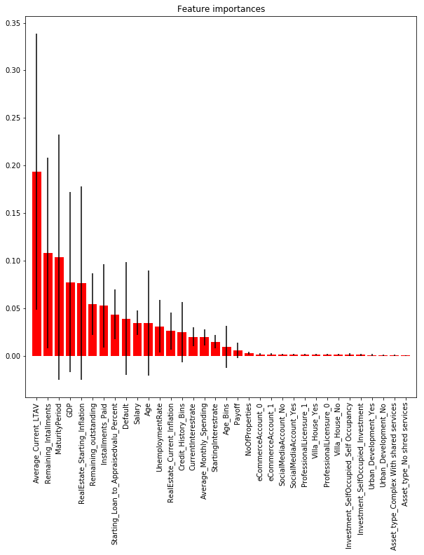

```python
#Plotting the Feature Importances
importances = best_grid.feature_importances_
std = np.std([tree.feature_importances_ for tree in best_grid.estimators_],
             axis=0)
indices = np.argsort(importances)[::-1]

# Print the feature ranking
print("Feature ranking:")

for f in range(X.shape[1]):
    print("%d. feature %d (%f)" % (f + 1, indices[f], importances[indices[f]]))

# Plot the feature importances of the forest
plt.figure(1, figsize=(10,10))
plt.title("Feature importances")
plt.bar(range(X.shape[1]), importances[indices],
       color="r", yerr=std[indices], align="center")
plt.xticks(range(X.shape[1]),X.columns[indices], rotation = 90)
plt.xlim([-1, X.shape[1]])
plt.show()
```

### Random Forest v0.2 with Important Features

```python
#Dropping Variables with low importance and saving it in a new dataframe "df_RF_best_features"
df_RF_best_features = df_model.drop(['ProfessionalLicensure_0',
       'ProfessionalLicensure_1', 'eCommerceAccount_0', 'eCommerceAccount_1',
       'SocialMediaAccount_No', 'SocialMediaAccount_Yes',
       'Asset_type_Complex With shared services',
       'Asset_type_No shred services', 'Urban_Development_No',
       'Urban_Development_Yes', 'Villa_House_No', 'Villa_House_Yes',
       'Investment_SelfOccupied_Investment',
       'Investment_SelfOccupied_Self Occupancy'],axis = 1)
```

```python
#Splitting the data to train and test
X_train, X_test, y_train, y_test = train_test_split(df_RF_best_features, y, test_size=0.25, random_state=42)
```

```python
# Scale the data to be between -1 and 1
from sklearn.preprocessing import StandardScaler

scaler = StandardScaler()
scaler.fit(X_train)
X_train = scaler.transform(X_train)
X_test = scaler.transform(X_test)
```

```python
from sklearn.model_selection import GridSearchCV
# Create the parameter grid based on the results of random search
param_grid = {
    'bootstrap': [True],
    'max_depth': [80, 90, 100, 110],
    'max_features': [2, 3],
    'min_samples_leaf': [3, 4, 5],
    'min_samples_split': [8, 10, 12],
    'n_estimators': [100, 200, 300]
}
# Create a based model
rf = RandomForestRegressor()
# Instantiate the grid search model
grid_search = GridSearchCV(estimator = rf, param_grid = param_grid,
                          cv = 5, n_jobs = -1, verbose = 2)
```

```python
# Fit the grid search to the data
grid_search.fit(X_train, y_train)
grid_search.best_params_
```

```
Fitting 5 folds for each of 216 candidates, totalling 1080 fits
```

```
[Parallel(n_jobs=-1)]: Using backend LokyBackend with 4 concurrent workers.
[Parallel(n_jobs=-1)]: Done  33 tasks      | elapsed:   46.5s
[Parallel(n_jobs=-1)]: Done 154 tasks      | elapsed:  3.7min
[Parallel(n_jobs=-1)]: Done 357 tasks      | elapsed:  8.6min
[Parallel(n_jobs=-1)]: Done 640 tasks      | elapsed: 14.7min
[Parallel(n_jobs=-1)]: Done 1005 tasks      | elapsed: 23.1min
[Parallel(n_jobs=-1)]: Done 1080 out of 1080 | elapsed: 24.9min finished
```

```
{'bootstrap': True,
 'max_depth': 100,
 'max_features': 3,
 'min_samples_leaf': 3,
 'min_samples_split': 8,
 'n_estimators': 300}
```

```python
from sklearn.model_selection import RandomizedSearchCV

best_grid = grid_search.best_estimator_
grid_accuracy = evaluate(best_grid, X_test, y_test)
```

```
Model Performance
RMSE 23.134314619588885
Average Error: 16.0922 degrees.
Accuracy = 97.05%.
```

## XGBOOST

```python
from sklearn.model_selection import cross_val_score,KFold
from sklearn.metrics import mean_absolute_error
import matplotlib.pyplot as plt
from sklearn.model_selection import GridSearchCV   #Perforing grid search
from scipy.stats import skew
from collections import OrderedDict
import xgboost
from sklearn import  tree, linear_model
from sklearn.svm.libsvm import cross_validation
from sklearn.model_selection import train_test_split
from sklearn.metrics import explained_variance_score
from xgboost import XGBRegressor
```

```python
X_train, X_test, y_train, y_test = train_test_split(X, y, test_size=0.3, random_state=101)
```

```python
# Let's try XGboost algorithm to see if we can get better results
xgb = XGBRegressor(n_estimators=400,
                           learning_rate=0.03,
                           gamma=0,
                           subsample=0.85,
                           colsample_bytree=0.8,
                           max_depth=7)
```

```python
%time xgb.fit(X_train,y_train)
```

```
Wall time: 16.8 s
```

```
XGBRegressor(base_score=0.5, booster='gbtree', colsample_bylevel=1,
       colsample_bytree=0.8, gamma=0, learning_rate=0.03, max_delta_step=0,
       max_depth=7, min_child_weight=1, missing=None, n_estimators=400,
       n_jobs=1, nthread=None, objective='reg:linear', random_state=0,
       reg_alpha=0, reg_lambda=1, scale_pos_weight=1, seed=None,
       silent=True, subsample=0.85)
```

```python
predictions = xgb.predict(X_test)
print(explained_variance_score(predictions,y_test))
```

```
0.7064617734362328
```

```python
from sklearn import metrics

print('RMSE:', np.sqrt(metrics.mean_squared_error(predictions,y_test)))
```

```
RMSE: 70.11905876736587
```

## NEURAL NETS

```python
X_train, X_validation, y_train, y_validation = train_test_split(X, y, test_size=0.25, random_state=42)
```

```python
import keras

# Convert data as np.array
features = np.array(X_train)
targets = np.array(y_train)
features_validation= np.array(X_validation)
targets_validation = np.array(y_validation)

print(features[:10])
print(targets[:10])
```

```
[[ 1.36600000e+03  1.00000000e+00  3.90000000e+01  9.00000000e+01
   6.25000000e+00  6.25000000e+00  2.26290000e+00  1.79261818e+00
   7.59942832e-01  7.12272727e+00  4.60000000e+01  9.70000000e+01
   1.43000000e+02  2.81243270e+05  1.15304869e+02  1.00000000e+00
   0.00000000e+00  3.30988761e-01  3.00000000e+00  4.00000000e+00
   1.00000000e+00  0.00000000e+00  1.00000000e+00  0.00000000e+00
   1.00000000e+00  0.00000000e+00  1.00000000e+00  0.00000000e+00
   1.00000000e+00  0.00000000e+00  1.00000000e+00  0.00000000e+00
   0.00000000e+00  1.00000000e+00]
 [ 1.44900000e+03  1.00000000e+00  3.90000000e+01  5.35000000e+01
   5.00000000e+00  3.96959459e+00  2.21910000e+00  1.77427838e+00
   1.31463497e+00  7.11351351e+00  6.00000000e+01  8.30000000e+01
   1.43000000e+02  3.44016820e+05  6.77763197e+01  0.00000000e+00
   0.00000000e+00  2.06225547e-01  3.00000000e+00  5.00000000e+00
   0.00000000e+00  1.00000000e+00  0.00000000e+00  1.00000000e+00
   0.00000000e+00  1.00000000e+00  0.00000000e+00  1.00000000e+00
   1.00000000e+00  0.00000000e+00  0.00000000e+00  1.00000000e+00
   0.00000000e+00  1.00000000e+00]
 [ 4.89194676e+03  1.00000000e+00  3.60000000e+01  7.58000000e+01
   5.37500000e+00  5.37500000e+00  1.86910000e+00  2.12360714e+00
   2.65640206e+00  4.89285714e+00  3.10000000e+01  1.01000000e+02
   1.32000000e+02  4.23894560e+05  6.41646301e+01  0.00000000e+00
   1.00000000e+00  4.18179984e-01  3.00000000e+00  3.00000000e+00
   0.00000000e+00  1.00000000e+00  1.00000000e+00  0.00000000e+00
   0.00000000e+00  1.00000000e+00  0.00000000e+00  1.00000000e+00
   1.00000000e+00  0.00000000e+00  0.00000000e+00  1.00000000e+00
   0.00000000e+00  1.00000000e+00]
 [ 1.97800000e+03  2.00000000e+00  3.60000000e+01  9.00000000e+01
   0.00000000e+00  8.73333333e+00  1.86910000e+00  2.16226667e+00
   2.56246962e+00  4.79166667e+00  3.10000000e+01  1.07000000e+02
   1.38000000e+02  8.84992200e+04  7.67114396e+01  0.00000000e+00
   0.00000000e+00  3.03466871e-01  3.00000000e+00  3.00000000e+00
   0.00000000e+00  1.00000000e+00  0.00000000e+00  1.00000000e+00
   0.00000000e+00  1.00000000e+00  0.00000000e+00  1.00000000e+00
   1.00000000e+00  0.00000000e+00  0.00000000e+00  1.00000000e+00
   0.00000000e+00  1.00000000e+00]
 [ 2.74263794e+03  1.00000000e+00  3.70000000e+01  8.00000000e+01
   6.00000000e+00  4.31034483e+00  2.19670000e+00  1.66472759e+00
   1.03708133e+00  7.76551724e+00  5.90000000e+01  9.00000000e+01
   1.49000000e+02  4.29310680e+05  1.02326459e+02  0.00000000e+00
```

[output cut: 36 more lines]

```
   0.00000000e+00  3.24901250e-01  3.00000000e+00  3.00000000e+00
   0.00000000e+00  1.00000000e+00  0.00000000e+00  1.00000000e+00
   0.00000000e+00  1.00000000e+00  0.00000000e+00  1.00000000e+00
   1.00000000e+00  0.00000000e+00  0.00000000e+00  1.00000000e+00
   0.00000000e+00  1.00000000e+00]
 [ 1.09733480e+03  1.00000000e+00  4.00000000e+01  8.00000000e+01
   8.12500000e+00  8.12500000e+00  1.61270000e+00  2.13304167e+00
   2.75539349e+00  4.92500000e+00  2.90000000e+01  1.06000000e+02
   1.35000000e+02  1.74611260e+05  5.97171472e+01  0.00000000e+00
   1.00000000e+00  7.23025314e-01  3.00000000e+00  3.00000000e+00
   1.00000000e+00  0.00000000e+00  0.00000000e+00  1.00000000e+00
   1.00000000e+00  0.00000000e+00  0.00000000e+00  1.00000000e+00
   1.00000000e+00  0.00000000e+00  0.00000000e+00  1.00000000e+00
   0.00000000e+00  1.00000000e+00]]
[381 647 703 519 534 537 712 494 672 794]
```

```python
from keras.models import Sequential
from keras.layers.core import Dense, Dropout, Activation


# Building the model
model = Sequential()
model.add(Dense(32, activation='relu', input_shape=(X_train.shape[1],)))
model.add(Dropout(.15))
model.add(Dense(16, activation='relu'))
model.add(Dropout(.15))
model.add(Dense(8, activation='relu'))
model.add(Dropout(.15))

model.add(Dense(1))

# Compiling the model
model.compile(loss = 'mse', optimizer='adam', metrics=['mse']) #mse: mean_square_error
model.summary()
```

```
_________________________________________________________________
Layer (type)                 Output Shape              Param #
=================================================================
dense_1 (Dense)              (None, 32)                1120
_________________________________________________________________
dropout_1 (Dropout)          (None, 32)                0
_________________________________________________________________
dense_2 (Dense)              (None, 16)                528
_________________________________________________________________
dropout_2 (Dropout)          (None, 16)                0
_________________________________________________________________
dense_3 (Dense)              (None, 8)                 136
_________________________________________________________________
dropout_3 (Dropout)          (None, 8)                 0
_________________________________________________________________
dense_4 (Dense)              (None, 1)                 9
=================================================================
Total params: 1,793
Trainable params: 1,793
Non-trainable params: 0
_________________________________________________________________
```

```python
# Training the model
epochs_tot = 10000
epochs_step = 1000
epochs_ratio = int(epochs_tot / epochs_step)
hist =np.array([])

for i in range(epochs_ratio):
    history = model.fit(features, targets, epochs=epochs_step, batch_size=128, verbose=0)

    # Evaluating the model on the training and testing set
    print("Step : " , i * epochs_step, "/", epochs_tot)
    score = model.evaluate(features, targets)
    print("Training MSE:", score[1])
    score = model.evaluate(features_validation, targets_validation)
    print("Validation MSE:", score[1], "\n")
    hist = np.concatenate((hist, np.array(history.history['mean_squared_error'])), axis = 0)

# plot metrics
plt.plot(hist)
plt.show()
```

[output not shown]

## KNN Regression

```python
from sklearn.neighbors import KNeighborsRegressor
from sklearn.metrics import mean_squared_error

#With Hyper Parameters Tuning
#2-4,kNearestNeighbors
#importing modules
from sklearn.model_selection import GridSearchCV
from sklearn.neighbors import KNeighborsClassifier
#making the instance
model = KNeighborsClassifier(n_jobs=-1)
#Hyper Parameters Set
params = {'n_neighbors':[2, 3, 4, 5, 6,7,8,9,10],
          'n_jobs':[-1]}
#Making models with hyper parameters sets
model1 = GridSearchCV(model, param_grid=params, n_jobs=1)
#Learning
model1.fit(X_train,y_train)
#The best hyper parameters set
print("Best Hyper Parameters:\n",model1.best_params_)
#Prediction
prediction=model1.predict(X_test)
#importing the metrics module
from sklearn import metrics
#evaluation(RMSE)
print('RMSE:', np.sqrt(metrics.mean_squared_error(y_test, prediction)))
```

[output not shown]

```python
print(mean_squared_error(y_test, outputs))
print("RMSE", np.sqrt(metrics.mean_squared_error(y_test,outputs)))
```

[output not shown]

# PREPROCESSING ON TEST DATA

#### 1. Reading Data

```python
test = pd.read_excel("Test-1557286861129.xlsx")
test_paymenthistory = pd.read_excel("Test_PaymentHistory-1557286890755.xlsx")
```

```python
test_ID = test['CustomerID']
```

#### 2. Data Exploration

```python
print("test Shape", test.shape)
print("test_paymenthistory shape", test_paymenthistory.shape)
```

```python
test.head()
```

```python
test_paymenthistory.head()
```

#### Preprocessing on Test Dataset

```python
print('Nulls in test Data \n', test.isna().sum())

print('Nulls in test Data \n', test.isnull().sum())
```

##### Dropping duplicates (If any)

```python
print(test.shape)
test.drop_duplicates(inplace=True)
print(test.shape)
```

#### Calculating Age from DOB

```python
#Creating new column with current date
test['today'] = "2019-05-09"
test['today'] = pd.to_datetime(test['today'])
```

```python
#Converting column to datetime and calculating age
test['DOB'] = pd.to_datetime(test['DOB'])
test['Age'] = (test['today'] - test['DOB']).dt.days/365.25
test['Age'] = test['Age'].astype('int')
```

```python
test.head()
```

```python
df_test = test.drop(['DOB', 'today'],axis = 1)
```

```python
df_test.head()
```

#### Preprocessing on Test Payment Hisory Dataset

#### Checking for NaN Null values in the datasets

```python
print('Nulls in test_paymenthistory Data \n', test_paymenthistory.isna().sum())

print('Nulls in test_paymenthistory Data \n',test_paymenthistory.isnull().sum())
```

```python
test_paymenthistory.head()
```

##### Dropping duplicates (If any)

```python
print(test_paymenthistory.shape)
test_paymenthistory.drop_duplicates(inplace = True)
print(test_paymenthistory.shape)
```

##### Rearranging Columns

```python
test_paymenthistory = test_paymenthistory[['CustomerID',
                                             'Maturity_Period',
                                             'Starting_Instalment',
                                             'Current_Instalment_Sequence',
                                             'Starting_outstanding',
                                             'Current_Outstanding',
                                             'Starting_Loan_to_Appraisedvalu_Percent',
                                             'Current_Loan_to_Appraisedvalu_Percent',
                                             'StartingInterestrate',
                                             'CurrentInterestrate',
                                             'RealEstate_Starting_Inflation',
                                             'RealEstate_Current_Inflation',
                                             'GDP',
                                             'UnemploymentRate',
                                             'Asset_type',
                                             'Urban_Development',
                                             'Villa_House',
                                             'Investment_SelfOccupied',
                                             'Payment_Status']]
```

```python
test_paymenthistory.head()
```

#### Feature Engineering on test Payment History Dataset

##### 3.4 Mean of the following Market and Bank Factors / columns group by Customer ID

1. Starting Outstanding
2. Starting_Loan_to_Appraisedvalu_Percent
3. Starting Interest Rate
4. CurrentInterestrate
5. RealEstate_Starting_Inflation
6. RealEstate_Current_Inflation
7. GDP
8. UnemploymentRate

```python
df_test_TPH = test_paymenthistory.groupby('CustomerID', as_index=False)['Starting_outstanding',
                                                                    'Starting_Loan_to_Appraisedvalu_Percent',
                                                                    'StartingInterestrate',
                                                                    'CurrentInterestrate',
                                                                    'RealEstate_Starting_Inflation',
                                                                    'RealEstate_Current_Inflation',
                                                                    'GDP',
                                                                    'UnemploymentRate'].mean()
```

```python
df_test_TPH.head()
```

#### New Column - Calculating Instalments Paid so far (Max value of Current Instalment Sequence)

```python
test_Installments_Paid = test_paymenthistory.groupby(['CustomerID'], as_index=False).agg({'Current_Instalment_Sequence':'max'})
```

```python
#Adding this columns to final train payment dataframe
df_test_TPH['Installments_Paid'] = test_Installments_Paid['Current_Instalment_Sequence']
```

#### Creating New Column Instalments Remaining (Total instalments - Max(Current Instalment Sequence))

```python
test_Installments_Remaining = test_paymenthistory.groupby(['CustomerID'], as_index=False).agg({'Maturity_Period':'max'})
```

```python
df_test_TPH.head()
```

```python
#Creating new column "Remaining_Intallments" are getting the value from difference of maturity period and installments paid
df_test_TPH['Remaining_Intallments'] = test_Installments_Remaining['Maturity_Period'] - df_test_TPH['Installments_Paid']
```

```python
#Adding maturity period column to final Train paymment history dataframe
df_test_TPH['MaturityPeriod'] = test_Installments_Remaining['Maturity_Period']
```

#### Creating New Column Current Outstanding (Minimum values of Current Outstanding)

```python
test_Current_Outstanding = test_paymenthistory.groupby(['CustomerID'], as_index=False).agg({'Current_Outstanding':'min'})
```

```python
df_test_TPH['Remaining_outstanding'] = test_Current_Outstanding['Current_Outstanding']
```

```python
df_test_TPH.head()
```

##### Creating New Column Average EMI (Average(Max(Current_Outstanding - Min(Current_Outstanding)))

```python
#Maximum value of Current_Outstanding for each customer
test_Max_Current_Outstanding = test_paymenthistory.groupby(['CustomerID'], as_index=False).agg({'Current_Outstanding':'max'})

#Minimum value of Current_Outstanding for each customer
test_Min_Current_Outstanding = test_paymenthistory.groupby(['CustomerID'], as_index=False).agg({'Current_Outstanding':'min'})

#Count of installments of Current_Outstanding for each customer
test_Count_Current_Outstanding = test_paymenthistory.groupby(['CustomerID'], as_index=False).agg({'Current_Outstanding':'count'})

#Calculating Average EMI, Difference of Max value minus min value of Current Outstanding divived by Couont of Current Outstanding minus 1
df_test_TPH['Average_EMI'] = (test_Max_Current_Outstanding['Current_Outstanding'] - test_Min_Current_Outstanding['Current_Outstanding'])/(test_Count_Current_Outstanding['Current_Outstanding']-1)
```

```python
df_test_TPH.head()
```

#### Creating New column - Current Loan to Appraisal Value (Average Value)

```python
test_Average_Current_LTAV = test_paymenthistory.groupby(['CustomerID'], as_index=False).agg({'Current_Loan_to_Appraisedvalu_Percent':'mean'})
```

```python
df_test_TPH['Average_Current_LTAV'] = test_Average_Current_LTAV['Current_Loan_to_Appraisedvalu_Percent']
```

#### Creating 3 New Columns from Payment Status - Count of each payment type for each customer

```python
test_payment_values = test_paymenthistory.groupby(['CustomerID', 'Payment_Status']).size().reset_index(name = 'count')
```

```python
test_payment_values.head()
```

```python
from pandas import *
test_payment_new_cols = pivot_table(test_payment_values, values = 'count', index = ['CustomerID'], columns = ['Payment_Status'],
                               aggfunc = np.sum, fill_value = '0').astype('int')
```

```python
test_payment_new_cols.head()
```

```python
df_test_TPH = pd.merge(df_test_TPH, test_payment_new_cols, on='CustomerID')
```

```python
df_test_TPH.head()
```

##### Adding Remaining columns from Train Payment History dataset to df_TPH

```python
print(test_paymenthistory.shape)
print(df_test_TPH.shape)
```

```python
test_Remaining_Cols = ['CustomerID','Asset_type', 'Urban_Development', 'Villa_House','Investment_SelfOccupied']
df_test_Remaining_Cols= test_paymenthistory[test_Remaining_Cols]
df_test_Remaining_Cols.drop_duplicates(inplace=True)
print(df_test_Remaining_Cols.shape)
```

```python
df_test_TPH = pd.merge(df_test_TPH, df_test_Remaining_Cols, on='CustomerID')
```

```python
print(df_test_TPH.shape)
print(df_test_Remaining_Cols.shape)
print(df_test_TPH.shape)
df_test_TPH.head()
```

#### Merging All Dataframes after Preprocessing and Feature Engineering on both dataframes - Train(df_train) and Train Payment History (train_paymentHistory_df)

```python
#Merging with TRAIN Dataset
df_test_final = pd.merge(df_test, df_test_TPH, on='CustomerID')
```

```python
df_test_final.shape
```

#### Feature Engineering on combined dataset df_final

##### Creating New Column "Average Monthly Spending" by adding Utility and Average EMI and dividing with Salary

```python
df_test_final['Average_Monthly_Spending'] = (df_test_final['UtilitySpending'] + df_test_final['Average_EMI'])/df_test_final['Salary']
```

```python
df_test_final.head()
```

```python
#Dropping Utility and Average_EMI column
df_test_final.drop(['UtilitySpending', 'Average_EMI'], axis = 1, inplace=True)
print(df_test_final.shape)
```

```python
df_test_final.head(1)
```

##### Data Types Conversion

```python
test_cat_col = ['ProfessionalLicensure', 'eCommerceAccount', 'SocialMediaAccount','Asset_type',
          'Urban_Development', 'Villa_House', 'Investment_SelfOccupied']
```

```python
df_test_final[cat_col] = df_test_final[test_cat_col].astype('category')
```

```python
df_test_final.head()
```

##### Checking and removing variables with correlation more than 95%

```python
correlation_df_test_final = df_test_final.corr()
sns.heatmap(correlation_df_test_final)
```

[output not shown]

```python
#Dropping variables with high correlation
test_High_Corr_Cols = ['Starting_outstanding', 'Non-Payoff/Non-Default']
df_test_final.drop(High_Corr_Cols, axis = 1, inplace=True)
print(df_test_final.shape)
```

```python
df_test_final.head()
```

##### Drop customer Id and Dummification

```python
df_test_model = df_test_final.drop('CustomerID', axis =1)
```

```python
df_test_model = pd.get_dummies(df_test_model)
print(df_test_model.shape)
```

```python
df_test_model.head()
```

## Random Forest Predictions

```python
#Predicting on Test Data

test_predictions_2 = best_grid.predict(df_test_model)

test_predictions_2_RF['CreditRiskScore'] = pd.DataFrame(test_predictions_2)


test_predictions_2_RF['CustomerID'] = df_test_final['CustomerID']

test_predictions_2_RF.to_csv('test_predictions_2_RF.csv', index=False)
```